# White Wine Quality: Chemical Influence

by Callie Lamb

December 2021

## Introduction

Below, I will be exploring a tidy dataset of white wine to find out what physiochemical properties most influence the quality of taste and relate to others. The quality variable is based on taste testing scores between 0 and 10 (worst to best), all other variables are based on physiochemical tests.

I want to start by taking a look at the structure of the dataset.

```
## 'data.frame':    4898 obs. of  13 variables:
##  $ X                   : int  1 2 3 4 5 6 7 8 9 10 ...
##  $ fixed.acidity       : num  7 6.3 8.1 7.2 7.2 8.1 6.2 7 6.3 8.1 ...
##  $ volatile.acidity    : num  0.27 0.3 0.28 0.23 0.23 0.28 0.32 0.27 0.3 0.22 ...
##  $ citric.acid         : num  0.36 0.34 0.4 0.32 0.32 0.4 0.16 0.36 0.34 0.43 ...
##  $ residual.sugar      : num  20.7 1.6 6.9 8.5 8.5 6.9 7 20.7 1.6 1.5 ...
##  $ chlorides           : num  0.045 0.049 0.05 0.058 0.058 0.05 0.045 0.045 0.049 0.044 ...
##  $ free.sulfur.dioxide : num  45 14 30 47 47 30 30 45 14 28 ...
##  $ total.sulfur.dioxide: num  170 132 97 186 186 97 136 170 132 129 ...
##  $ density             : num  1.001 0.994 0.995 0.996 0.996 ...
##  $ pH                  : num  3 3.3 3.26 3.19 3.19 3.26 3.18 3 3.3 3.22 ...
##  $ sulphates           : num  0.45 0.49 0.44 0.4 0.4 0.44 0.47 0.45 0.49 0.45 ...
##  $ alcohol             : num  8.8 9.5 10.1 9.9 9.9 10.1 9.6 8.8 9.5 11 ...
##  $ quality             : int  6 6 6 6 6 6 6 6 6 6 ...
```

I am going to remove column “X”, as this column is the identifier and I don’t want these numbers included in any statistics. After that there will be 11 input variables and 1 output variable (quality), each with 4898 observations.

## Univariate Plots Section

Now I am going to create histogram plots and summary prints of each variable to get a better idea of how the observations are distributed.

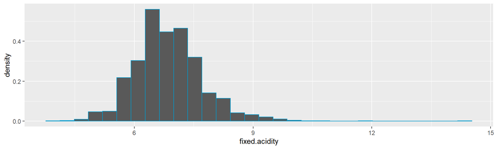

```
##    Min. 1st Qu.  Median    Mean 3rd Qu.    Max.
##   3.800   6.300   6.800   6.855   7.300  14.200
```

Fixed acidity appears to be normally distributed but is slightly right skewed.

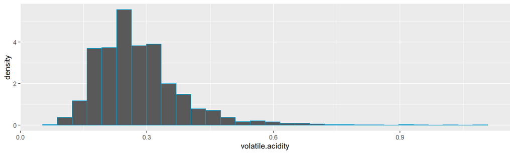

```
##    Min. 1st Qu.  Median    Mean 3rd Qu.    Max.
##  0.0800  0.2100  0.2600  0.2782  0.3200  1.1000
```

Volatile acidity is bell-curve shaped with uniform distribution on both sides of the peak, but becomes slightly right skewed.

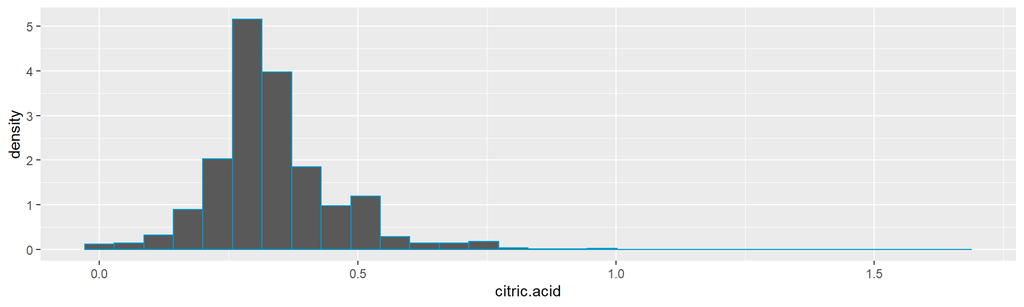

```
##    Min. 1st Qu.  Median    Mean 3rd Qu.    Max.
##  0.0000  0.2700  0.3200  0.3342  0.3900  1.6600
```

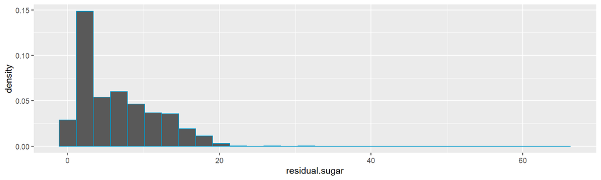

```
##    Min. 1st Qu.  Median    Mean 3rd Qu.    Max.
##   0.600   1.700   5.200   6.391   9.900  65.800
```

Residual sugar distribution is very right skewed.

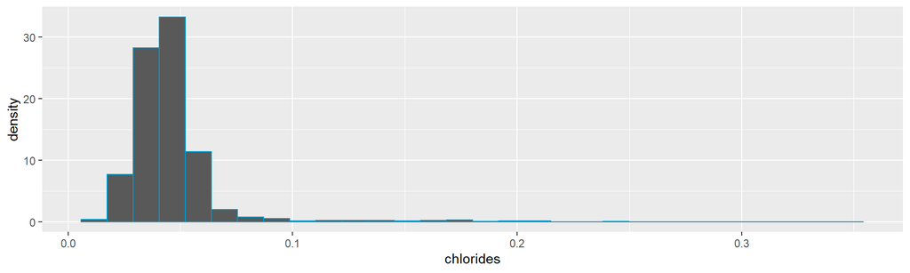

```
##    Min. 1st Qu.  Median    Mean 3rd Qu.    Max.
## 0.00900 0.03600 0.04300 0.04577 0.05000 0.34600
```

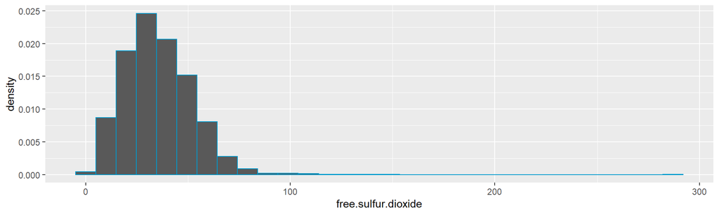

```
##    Min. 1st Qu.  Median    Mean 3rd Qu.    Max.
##    2.00   23.00   34.00   35.31   46.00  289.00
```

Free sulfur dioxide has a mostly normal distribution that is slightly right skewed.

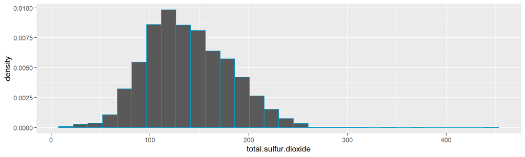

```
##    Min. 1st Qu.  Median    Mean 3rd Qu.    Max.
##     9.0   108.0   134.0   138.4   167.0   440.0
```

Total sulfur dioxide has a wide distribution that is right skewed.

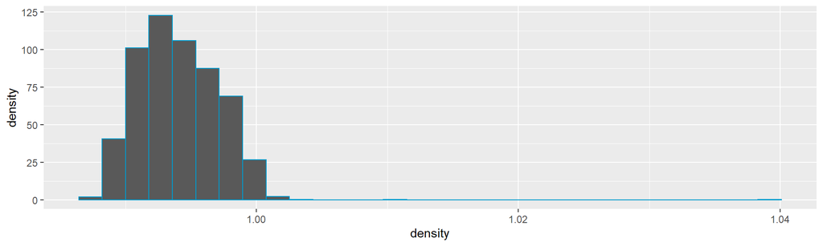

```
##    Min. 1st Qu.  Median    Mean 3rd Qu.    Max.
##  0.9871  0.9917  0.9937  0.9940  0.9961  1.0390
```

Density distribution is right skewed.

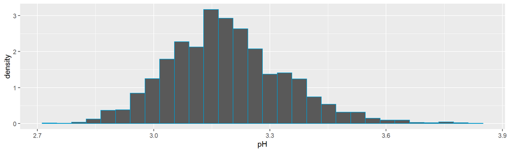

```
##    Min. 1st Qu.  Median    Mean 3rd Qu.    Max.
##   2.720   3.090   3.180   3.188   3.280   3.820
```

pH has a mostly symmetrical, wide distribution.

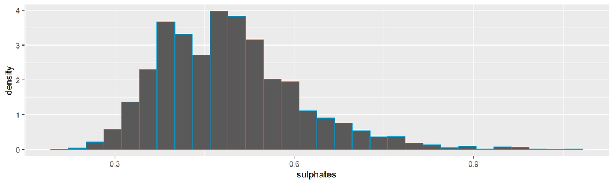

```
##    Min. 1st Qu.  Median    Mean 3rd Qu.    Max.
##  0.2200  0.4100  0.4700  0.4898  0.5500  1.0800
```

Sulphates have a wide distribution that is slightly right skewed.

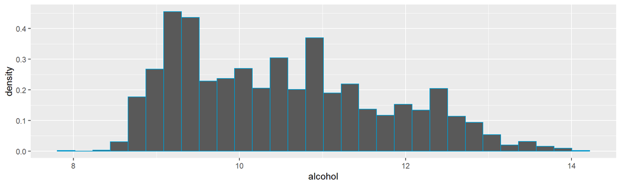

```
##    Min. 1st Qu.  Median    Mean 3rd Qu.    Max.
##    8.00    9.50   10.40   10.51   11.40   14.20
```

Alcohol has a right skewed, wide and uniform distribution.

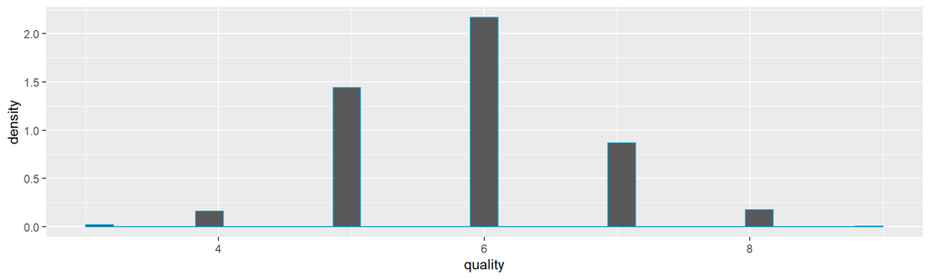

```
##    Min. 1st Qu.  Median    Mean 3rd Qu.    Max.
##   3.000   5.000   6.000   5.878   6.000   9.000
```

Most of the quality scores are 6, with 5 and 7 next in line.

### Univariate Analysis

1. What is the structure of your dataset?
- This is a tidy, multivariate dataset consisting of 12 variables and 4898 observations. 11 of the variables are numerical and 1 (quality) is an integer.
2. What is/are the main feature(s) of interest in your dataset?
- Quality is the main feature of this dataset.
3. What other features in the dataset do you think will help support your investigation into your feature(s) of interest?
- All of the other variables will each support my investigation of finding what chemical properties most affect the quality.
4. Did you create any new variables from existing variables in the dataset?
- I did not create any additional variables.
5. Of the features you investigated, were there any unusual distributions?
- Yes, citric.acid had a small peak to the right of the main peak. Residual.sugar is dense around 1 and 2, but spreads to the right over a wide range.
6. Did you perform any operations on the data to tidy, adjust, or change the form of the data? If so, why did you do this?
- I did not modify any parts of the data.

## Bivariate Plots Section

I think that the fastest way to identify correlations between variables would be to create a pairs plot.

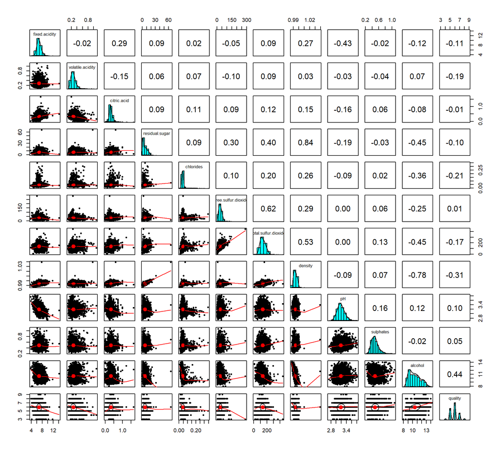

From the plot above, there are a few variables that I’d like to explore more. First, between residual.sugar and density with the correlation of 0.84.

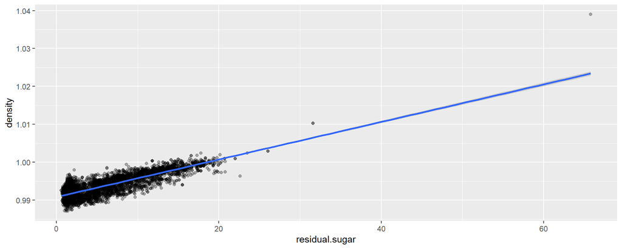

The graph shows a positive correlation between these two variables with the points tightly following along the mean correlation line.

Next, between free.sulfur.dioxide and total.sulfur.dioxide with the correlation of 0.62.

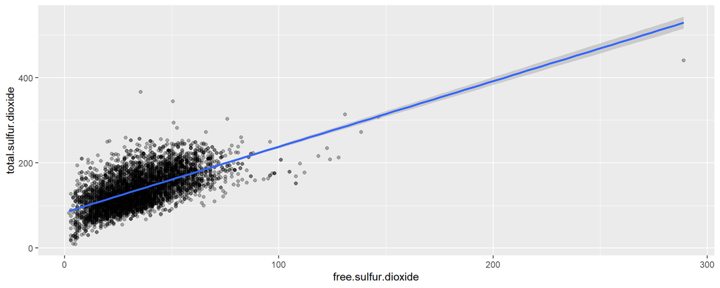

Next, between total.sulfur.dioxide and density with the correlation of 0.53.

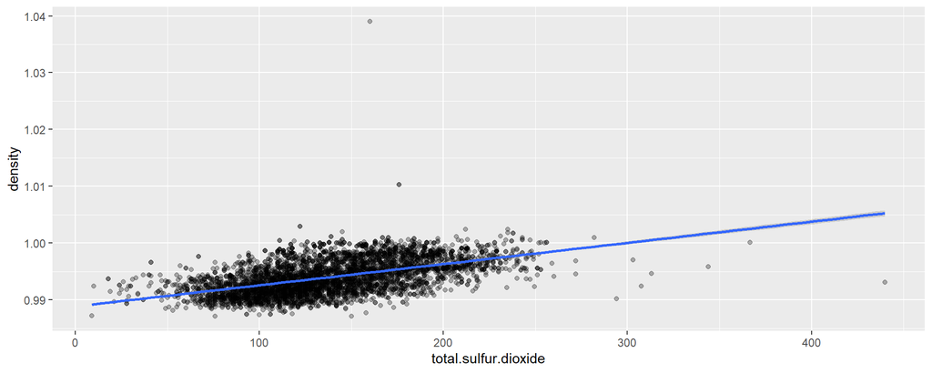

Next, between residual.sugar and total.sulfur.dioxide with the correlation of 0.40.

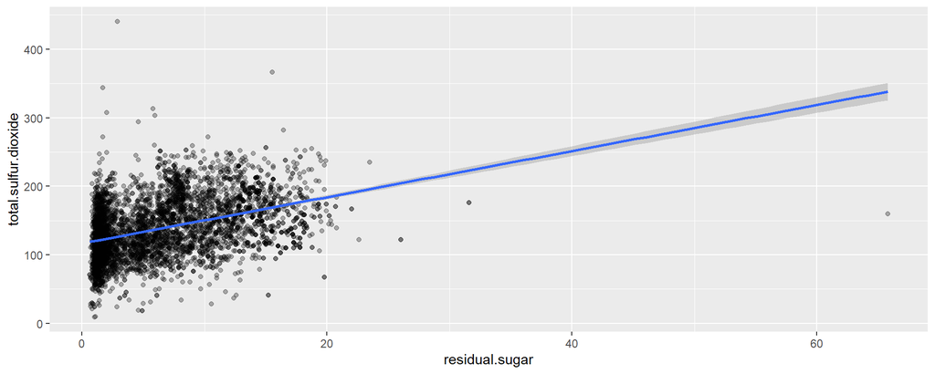

The graph shows a positive correlation between these two variables however, the spread is wide between the low and high ends of total.sulfur.dioxide.

Last, between alcohol and quality with the correlation of 0.44.

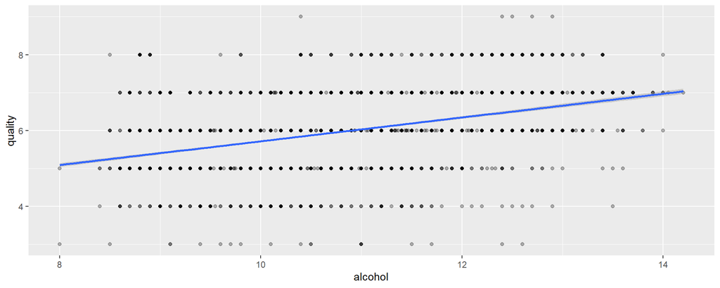

The graph shows a positive correlation between these two variables.

### Bivariate Analysis

1. How did the feature(s) of interest vary with other features in the dataset?
- From the pairs correlation plot I could see that as fixed.acidity increases, the quality decreases. When free.sulfur.dioxide is low, there is a positive correlation with quality. The quality then starts dropping as free.sulfur.dioxide increases. This is the same with total.sulfur.dioxide. Alcohol was the highest scoring input variable with the output variable, quality.
2. Did you observe any interesting relationships between the other features (not the main feature(s) of interest)?
- I found it interesting that density and alcohol have the lowest correlation, yet density and residual.sugar have the strongest correlation.
3. What was the strongest relationship you found?
- For the input variables, residual.sugar and density had the highest correlation with a score of 0.839. The highest correlation with the output variable of quality was with the alcohol variable. The strongest negative correlation was between density and alcohol with a score of -0.78.

## Multivariate Plots Section

Based on the plots above, I’m going to zoom in and plot using facet_wrap to break the plots out by quality score.

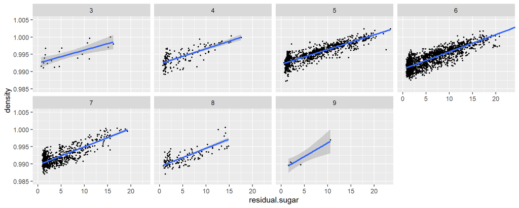

Here, I can see that residual.sugar and density have a positive correlation with every unique quality observation. It also appears that as the means between residual.sugar and density decrease, quality increases.

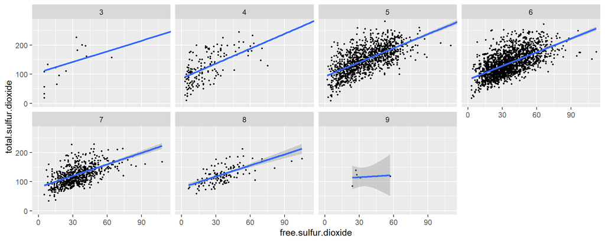

total.sulfur.dioxide and free.sulfur.dioxide also have a positive correlation with every unique quality observation. However, after the quality score of 6, the positive correlation starts to decrease.

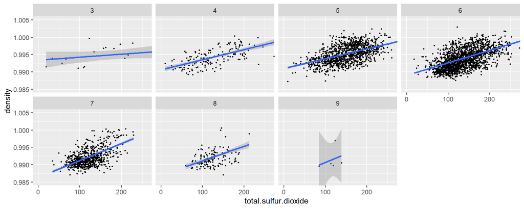

total.sulfur.dioxide and density also have a positive correlation with every unique quality observation.

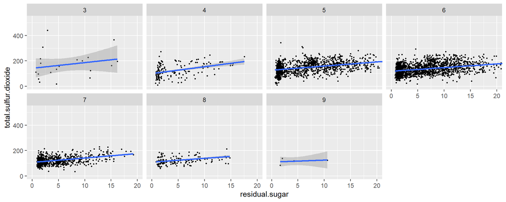

residual.sugar and total.sulfur.dioxide have a positive correlation with each unique quality observation, although not as strong as the plots above.

### Multivariate Analysis

1. Were there features that strengthened each other in terms of looking at your feature(s) of interest?
- Yes. With quality brought into the correlations between residual.sugar and density, total.sulfur.dioxide and free.sulfur.dioxide, and between total.sulfur.dioxide and density, the positive correlations strengthened.
2. Were there any interesting or surprising interactions between features?
- Yes. The correlation between alcohol and quality is positive yet, none of the other input variables had a strong positive correlation with alcohol.

## Final Plots and Summary

### Plot One

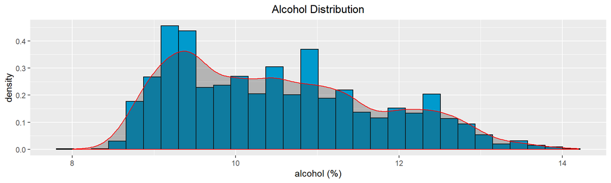

### Description One

I chose alcohol content as my first plot because I found it interesting how wide and somewhat uniform the distribution is compared to all of the other variables.

### Plot Two

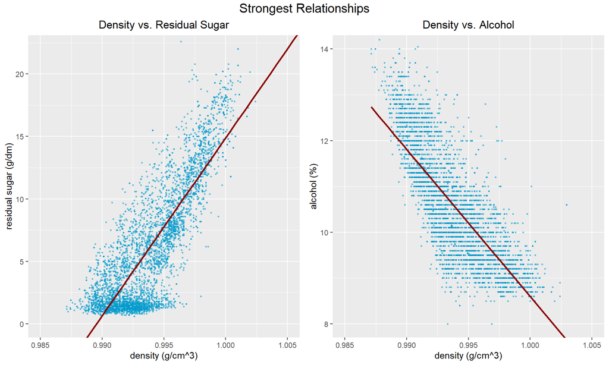

### Description Two

I chose this as my second plot to show how there is a strong positive correlation between density and residual.sugar, and a strong negative correlation between density and alcohol.

### Plot Three

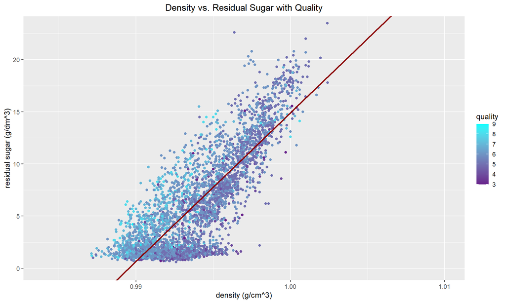

### Description Three

I chose this plot to reflect the strong positive correlation between residual.sugar and density with quality reflected in the point colors.

## Reflection

Some of the struggles I had were sticking to the idea of a “quick and dirty” analysis. Through majority of this project I wanted to make beautiful looking plots, so I spent a lot of wasted time researching plot aesthetics and not actually analyzing the data. Once I realized what I was doing and that I needed to keep it “quick and dirty” the analysis and plotting came more easily.

I do think this dataset could be used in machine learning for predictive models of what physiochemicals influence the taste of white wine. However, it should be used alongside many other similar datasets from controlled taste testing events. It should also be noted that the sensory quality score of wine would most likely vary in different regions of the world. What is considered a great tasting wine in one region, may be completely opposite in another.

The dataset used in this analysis was downloaded from:

- https://s3.amazonaws.com/udacity-hosted-downloads/ud651/wineQualityWhites.csv

For more information regarding this dataset, please visit these sites [Cortez et al., 2009]:

- http://dx.doi.org/10.1016/j.dss.2009.05.016
- http://www3.dsi.uminho.pt/pcortez/winequality09.pdf
- http://www3.dsi.uminho.pt/pcortez/dss09.bib